# Miscellaneous to dos from meetings

Hannah Andrews

6/7/2021

# Meeting 6/3/21

## Spiritual healing and prayer crosstabs

Check overlap between spiritual healing and prayer. If all those who practice spiritual healing also pray, that may be the cause of the low MSAi’s from the KMO test. All the variance in spiritual healing would be common with prayer.

0 = No, 1 = Yes

```
##    Cell Contents
## |-------------------------|
## |                   Count |
## |           Total Percent |
## |-------------------------|
##
## ==========================================
##                      acams$aPrayer
## acams$aSpiritHeal        0       1   Total
## ------------------------------------------
## 0                    4304    1657    5961
##                      69.9%   26.9%
## ------------------------------------------
## 1                      11     185     196
##                       0.2%    3.0%
## ------------------------------------------
## Total                4315    1842    6157
## ==========================================
```

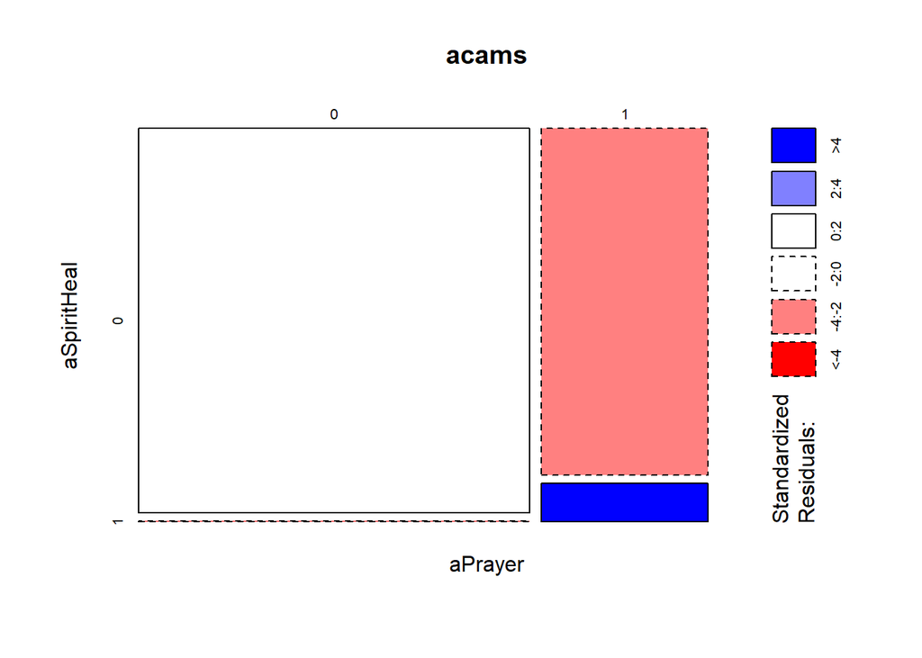

Nearly 70% respond no to both. 26% of those who prayer do not use spiritual healing. Among those who use spiritual healing, less than 1% do not use prayer compared to 3% who do use prayer.

Run crosstabs on all variables that load on more than one factor with variables loading on the same factors.

## Energy Healing

Energy healing loads on three factors in the four, five, and six factor models with all variables are included. Energy healing loads on two and five factor models when prayer and spiritual healing are excluded.

### Energy healing and prayer

All CAMs: loads with prayer in four factor model and five factor model

```
##
##        0    1
##   0 4295 1769
##   1   20   73
```

```
##
##               0           1
##   0 0.697579990 0.287315251
##   1 0.003248335 0.011856424
```

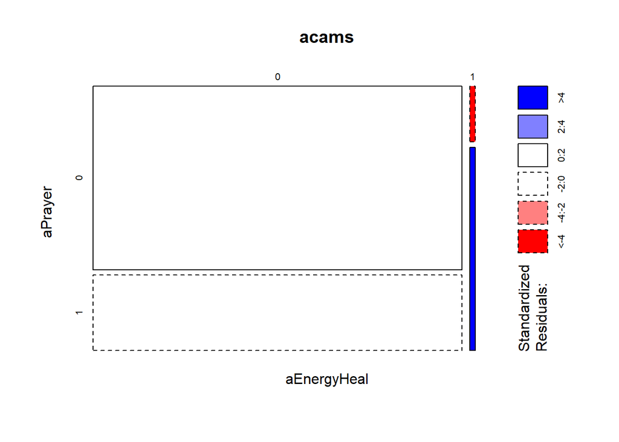

70% of the sample does not use energy healing or prayer. About 1% use both. 28% use prayer but not energy healing. Less than 1% use energy healing but not prayer.

### Energy healing and spiritual healing

```
##
##        0    1
##   0 5899  165
##   1   62   31
```

```
##
##              0          1
##   0 0.95809648 0.02679877
##   1 0.01006984 0.00503492
```

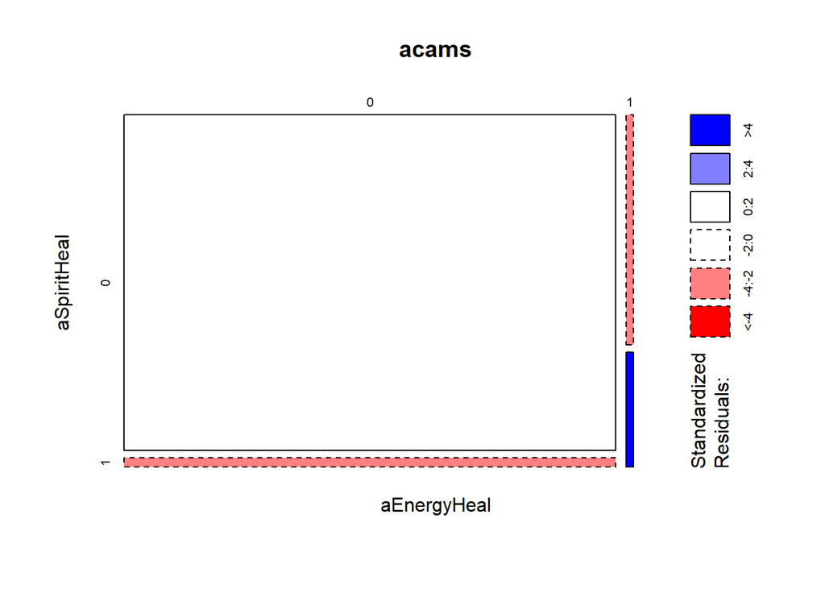

95% of the sample does not use spiritual or energy healing. Less than 1% use both. 1% use energy healing but not spiritual healing. 2.7% use spiritual healing but not energy healing.

### Energy healing and imagery techniques

```
##
##        0    1
##   0 5926  138
##   1   47   46
```

```
##
##               0           1
##   0 0.962481728 0.022413513
##   1 0.007633588 0.007471171
```

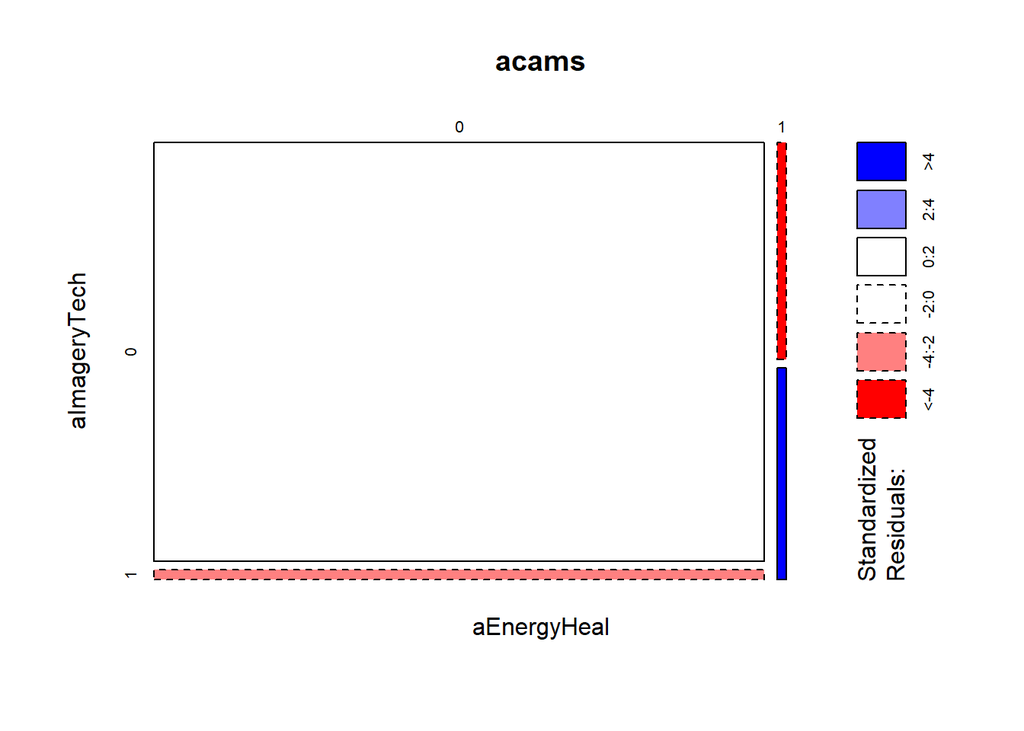

96% of the sample does not use energy healing or imagery techniques. Less than 1% use both. Less than 1% use energy healing but not imagery. 2.2% use imagery but not energy healing.

### Energy healing and hypnosis

```
##
##        0    1
##   0 6005   59
##   1   80   13
```

```
##
##               0           1
##   0 0.975312652 0.009582589
##   1 0.012993341 0.002111418
```

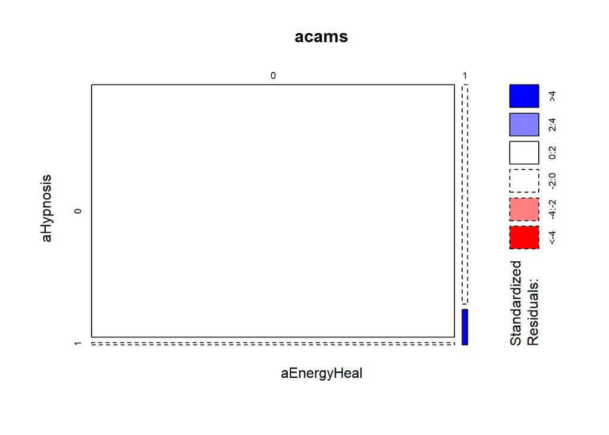

97.5% use neither energy healing or hypnosis. Less than 1% use both. 1.3% use energy healing but not hypnosis. About 1% use hypnosis but not energy healing.

### Energy healing and meditation

```
##
##        0    1
##   0 5328  736
##   1   16   77
```

```
##
##               0           1
##   0 0.865356505 0.119538736
##   1 0.002598668 0.012506091
```

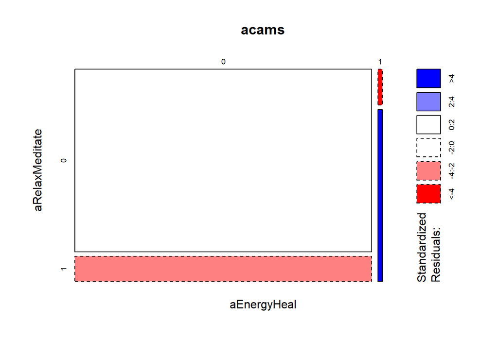

86% of the sample use neither meditation or energy healing. 1.3% use both. 12% use meditation but not energy healing. Less than 1% use energy healing but not meditation.

### Energy healing and biofeedback

```
##
##        0    1
##   0 6028   36
##   1   81   12
```

```
##
##               0           1
##   0 0.979048238 0.005847003
##   1 0.013155758 0.001949001
```

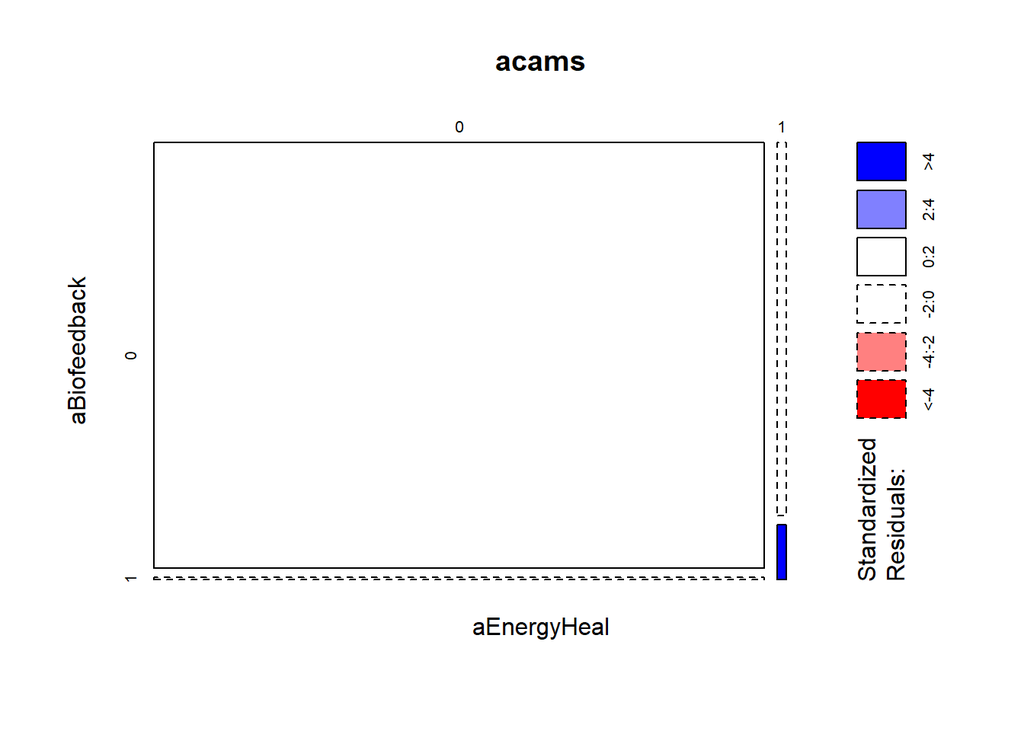

### Energy healing and special diet

```
##
##        0    1
##   0 5434  630
##   1   54   39
```

```
##
##               0           1
##   0 0.882572682 0.102322560
##   1 0.008770505 0.006334254
```

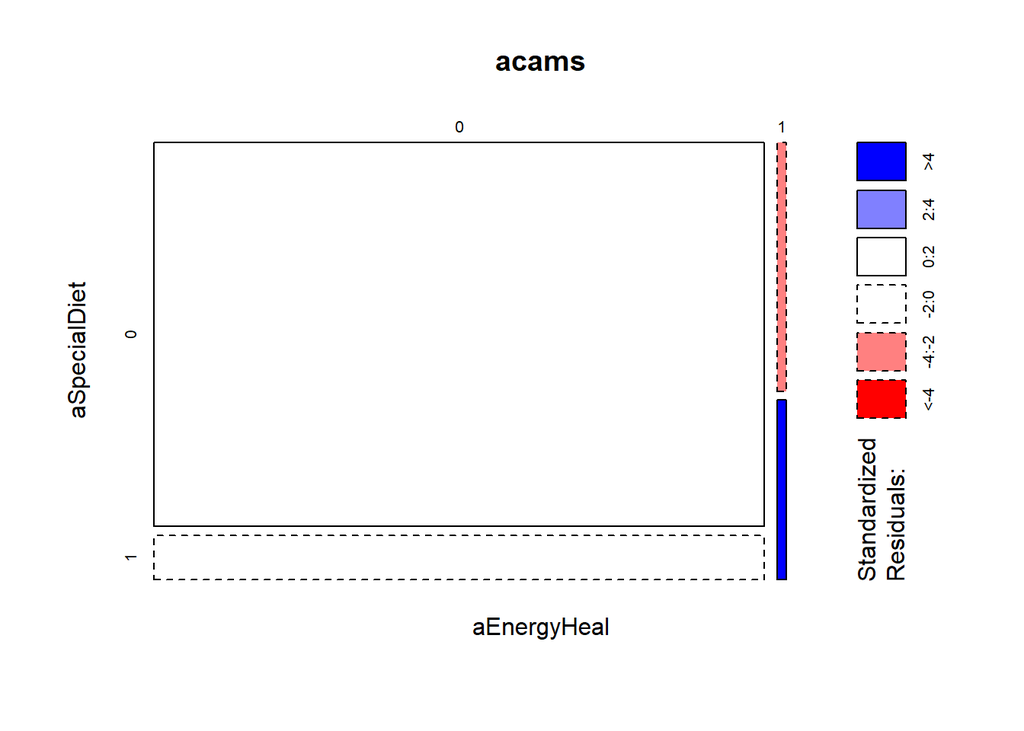

88% use neither. Less than 1% use both. 10% use a special diet not but energy healing. Less than 1% use energy healing but not a special diet.

### Energy healing and massage

```
##
##        0    1
##   0 5599  465
##   1   39   54
```

```
##
##               0           1
##   0 0.909371447 0.075523794
##   1 0.006334254 0.008770505
```

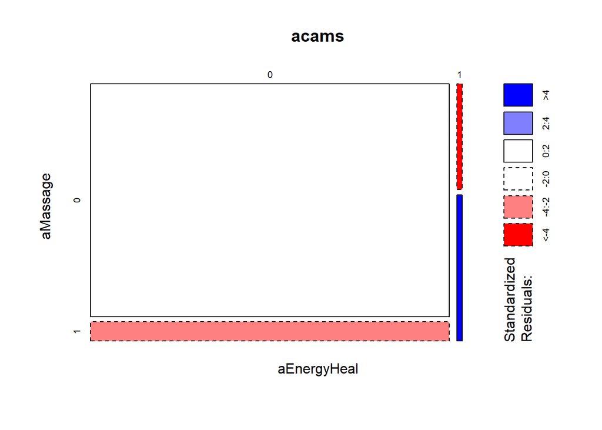

91% use neither. Less than 1% use both. About 8% use massage but not energy healing. Less than 1% use energy healing but not massage.

### Energy healing and homeopathy

```
##
##        0    1
##   0 5956  108
##   1   59   34
```

```
##
##               0           1
##   0 0.967354231 0.017541010
##   1 0.009582589 0.005522170
```

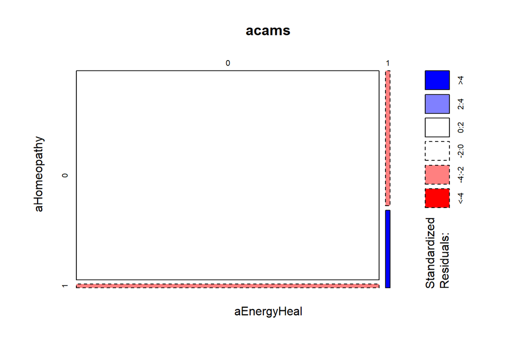

97% use neither. Less than 1% use both. About 2% use homeopathy but not energy healing. Less than 1% use energy healing but not homeopathy.

### Energy healing and vitamins

```
##
##        0    1
##   0 5813  251
##   1   62   31
```

```
##
##              0          1
##   0 0.94412863 0.04076661
##   1 0.01006984 0.00503492
```

[figure not shown]

94% use neither. Less than 1% use both. 4% use vitamins but not energy healing. 1% use energy healing but not vitamins.

### Energy healing and herbal

```
##
##        0    1
##   0 5816  248
##   1   40   53
```

```
##
##               0           1
##   0 0.944615884 0.040279357
##   1 0.006496670 0.008608088
```

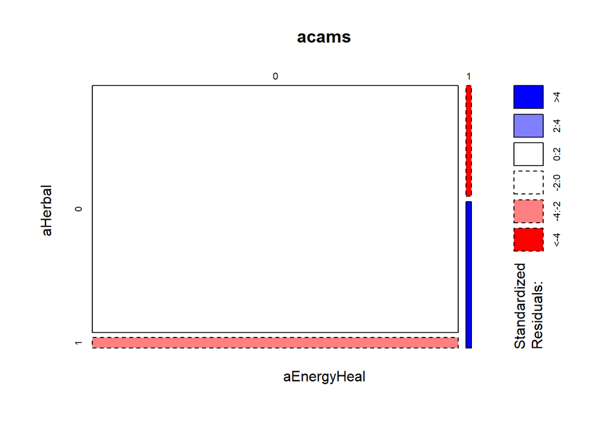

94% use neither. Less than 1% use both. Less than 1% use energy healing but not herbal therapy. 4% use herbal therapy but not energy healing.

### Energy healing and Exercise/Movement

```
##
##        0    1
##   0 5052 1012
##   1   27   66
```

```
##
##               0           1
##   0 0.820529479 0.164365763
##   1 0.004385253 0.010719506
```

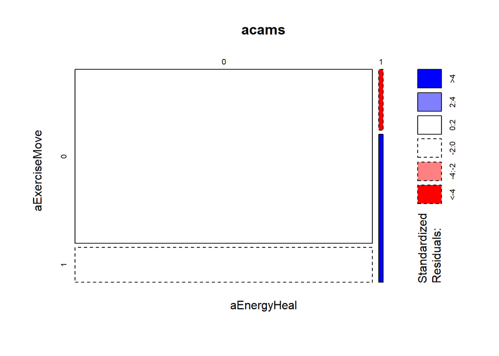

82% use neither. 1% use both. 16% use exercise or movement therapy but not energy healing. Less than 1% use energy healing but not exercise or movement therapy.

### Energy healing and chiropractic

```
##
##        0    1
##   0 5358  706
##   1   60   33
```

```
##
##               0           1
##   0 0.870229008 0.114666234
##   1 0.009745006 0.005359753
```

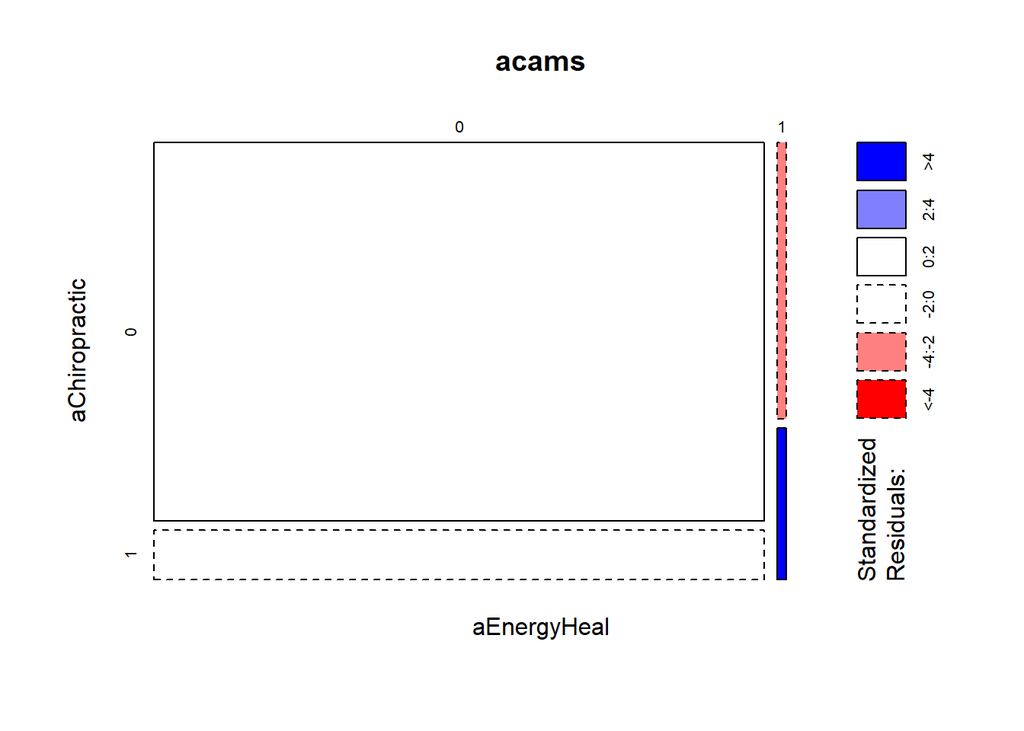

87% use neither. Less than 1% use both. 11% use chiropractic care but not energy healing. About 1% use energy healing but not chiropractic care.

### Energy healing and acupuncture

```
##
##        0    1
##   0 6006   58
##   1   77   16
```

```
##
##               0           1
##   0 0.975475069 0.009420172
##   1 0.012506091 0.002598668
```

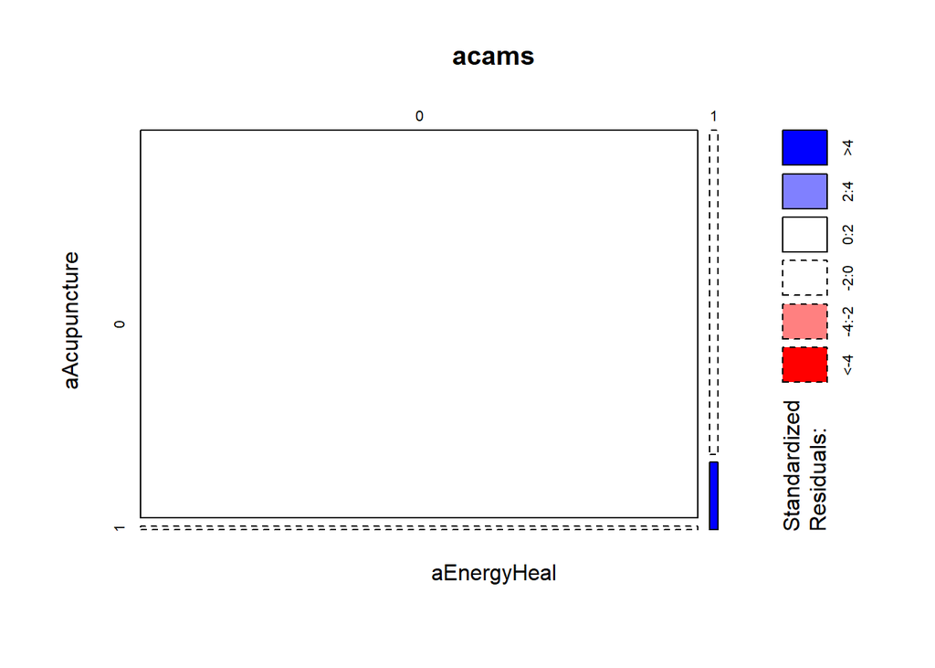

97.5% use neither. Less than 1% use both. Less than 1% use acupuncture but not energy healing. 1.3% use energy healing but not acupuncture.

## Massage

Drop spiritual healing and prayer: Loads on two factors in the four factor model

### Massage and Exercise/Movement

```
##
##        0    1
##   0 4856  782
##   1  223  296
```

```
##
##              0          1
##   0 0.78869579 0.12700991
##   1 0.03621894 0.04807536
```

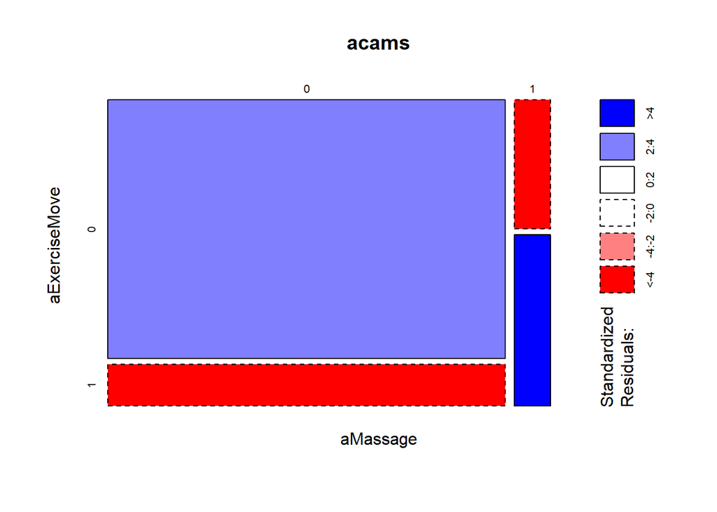

```
##
##        0    1
##   0 5103  535
##   1  315  204
```

```
##
##              0          1
##   0 0.82881273 0.08689297
##   1 0.05116128 0.03313302
```

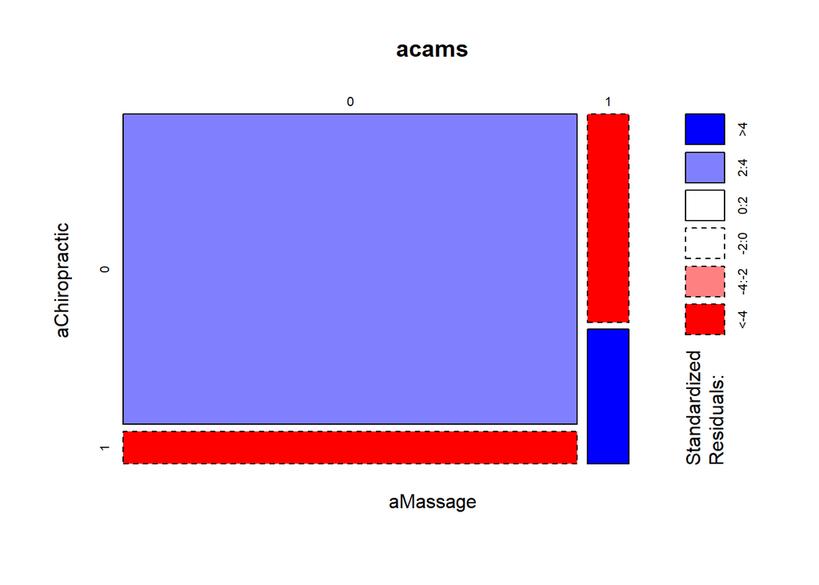

83% use neither. 3% use both. 9% use chiropractic care but not massage. 5% use massage but not chiropractic care.

## Acupuncture

Drop prayer and spiritual healing: loads on two factors in the 5 factor model.

### Acupuncture and Vitamins

```
##
##        0    1
##   0 5815  268
##   1   60   14
```

```
##
##               0           1
##   0 0.944453468 0.043527692
##   1 0.009745006 0.002273835
```

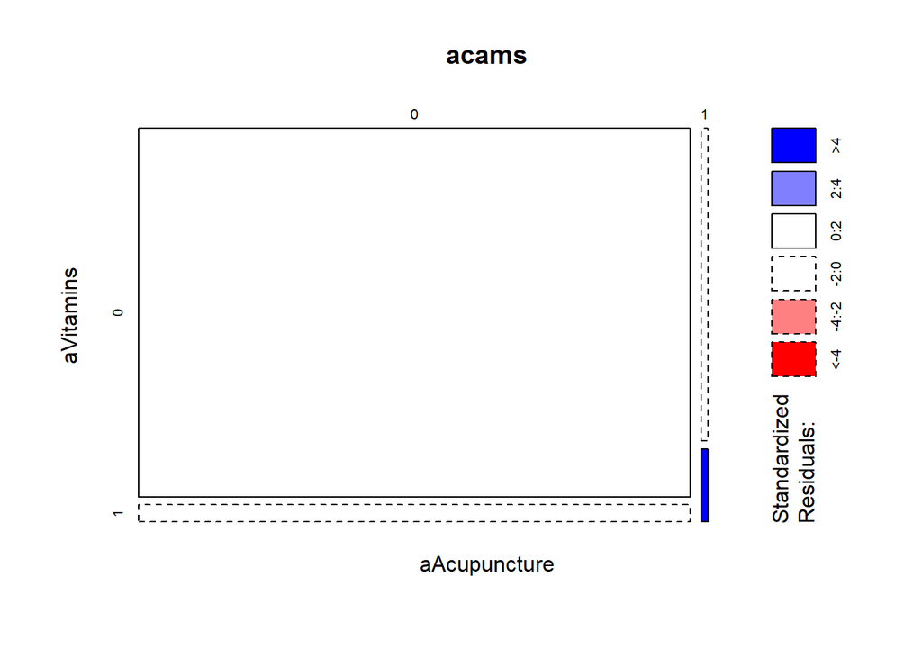

### Acupuncture and Herbal

```
##
##        0    1
##   0 5818  265
##   1   38   36
```

```
##
##               0           1
##   0 0.944940718 0.043040442
##   1 0.006171837 0.005847003
```

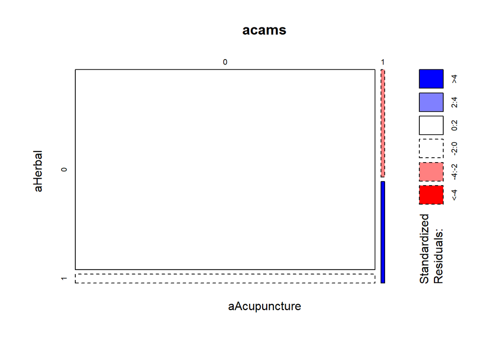

94% use neither. Less than 1% use both. 4% use herbal therapy but not acupuncture. Less than 1% use acupuncture but not herbal therapy.

### Acupuncture and Homeopathy

```
##
##        0    1
##   0 5963  120
##   1   52   22
```

```
##
##               0           1
##   0 0.968491148 0.019490011
##   1 0.008445672 0.003573169
```

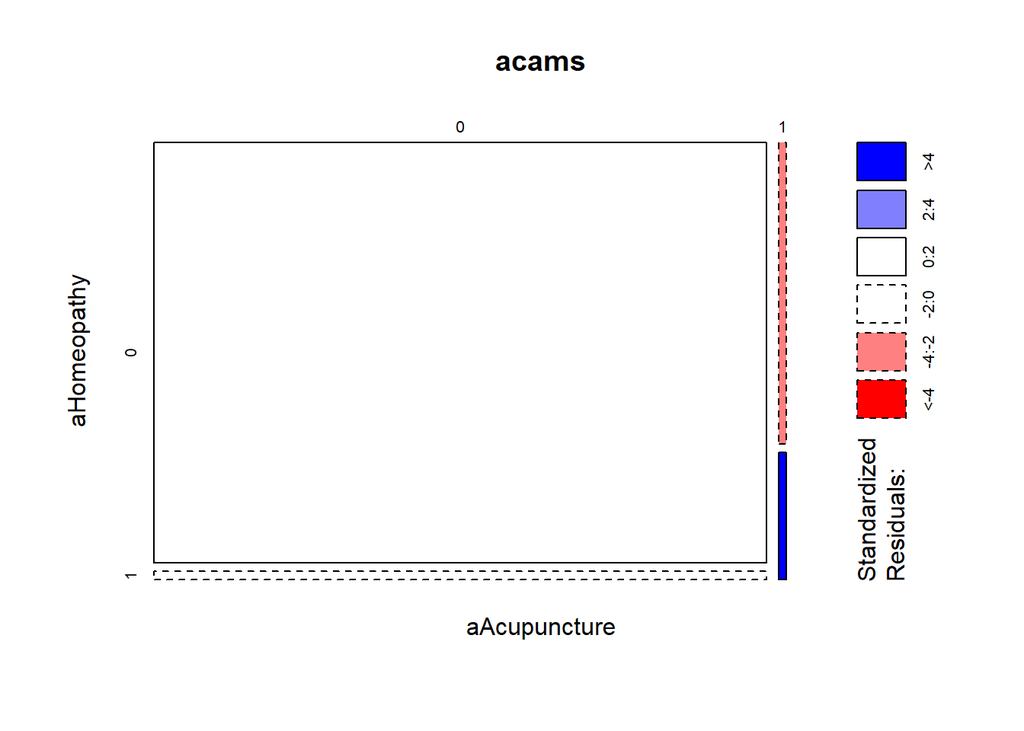

97% use neither. Less than 1% use both. 2% use homeopathy but not acupuncture. Less than 1% use acupuncture but not homeopathy.

### Acupuncture and Special Diet

```
##
##        0    1
##   0 5438  645
##   1   50   24
```

```
##
##               0           1
##   0 0.883222349 0.104758811
##   1 0.008120838 0.003898002
```

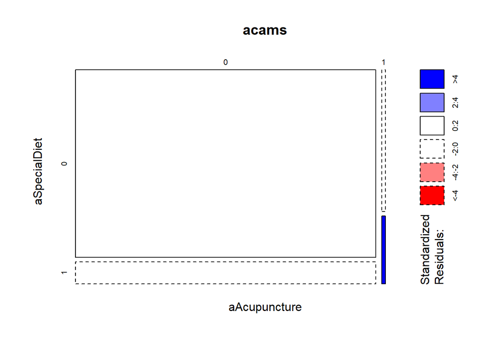

88% use neither. Less than 1% use both. 10% use a special diet but not acupuncture. Less than 1% use acupuncture but not a special diet.

### Acupuncture and Exercise Movement Therapy

```
##
##        0    1
##   0 5033 1050
##   1   46   28
```

```
##
##               0           1
##   0 0.817443560 0.170537599
##   1 0.007471171 0.004547669
```

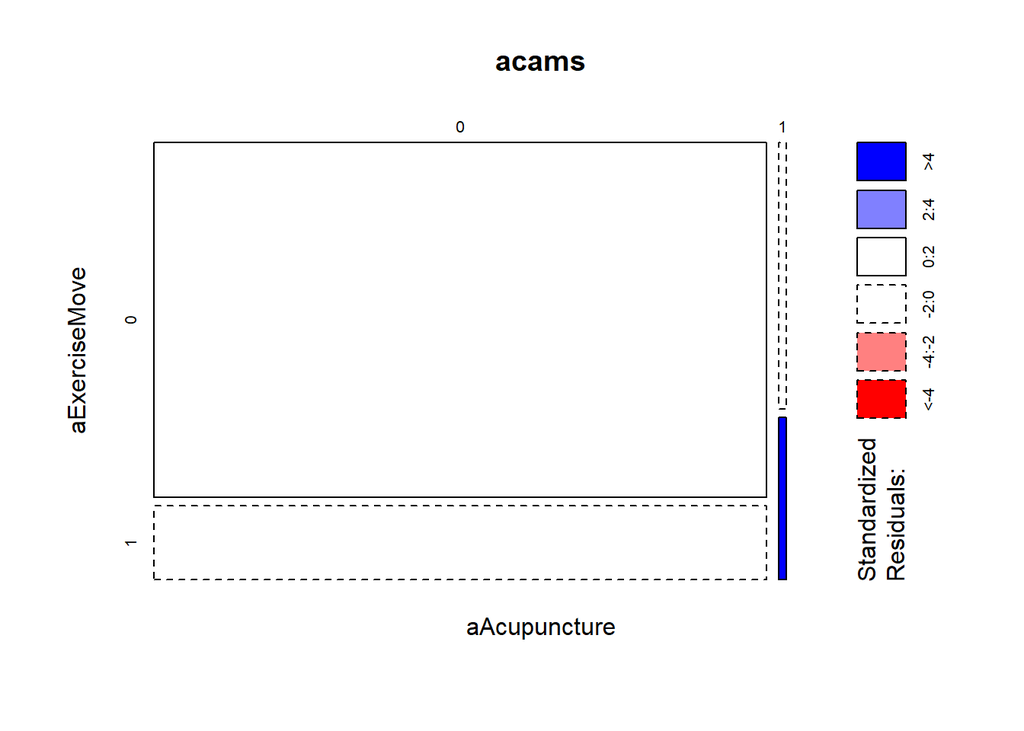

82% use neither. Less than 1% use both. 17% use exercise or movement therapy but not acupuncture. Less than 1% use acupuncture but not exercise or movement therapy.

## Exercise or Movement Therapy

Drop spiritual healing and prayer: loads on two factors in the five factor model.

### Exercise and Chiropractic

```
##
##        0    1
##   0 4573  506
##   1  845  233
```

```
##
##              0          1
##   0 0.74273185 0.08218288
##   1 0.13724216 0.03784311
```

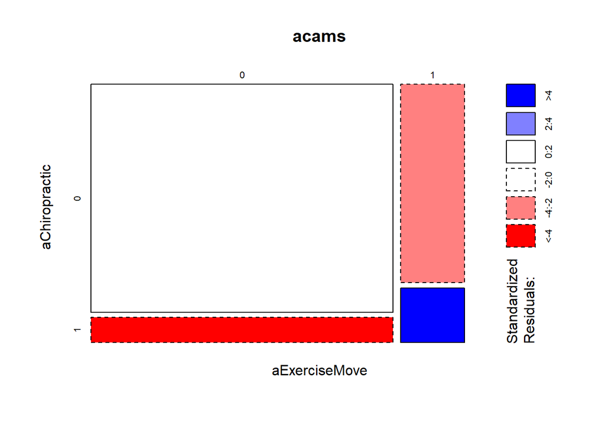

### Exercise and Massage

```
##
##        0    1
##   0 4856  223
##   1  782  296
```

```
##
##              0          1
##   0 0.78869579 0.03621894
##   1 0.12700991 0.04807536
```

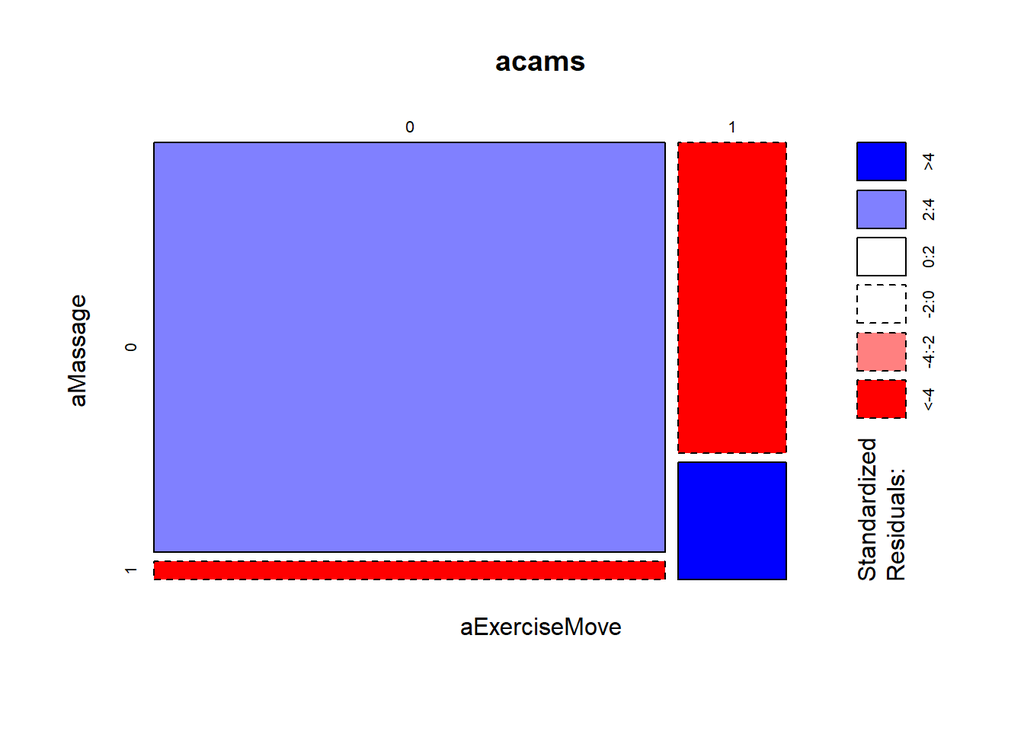

78.9% use neither. 4.8% use both. 3.6% use massage but not exercise or movement therapy. 12.7% use exercise or movement therapy but not massage.